# ITSI

Kacper Bryda, Rafał Kiełbasa, Szymon Ciesek

2025-05-14

## TASK 1

We chose to analyze data set with information about influence of diseases and drugs on human’s energy and oxygen saturation.

```r
library(ggplot2)
library(car)
library(fitdistrplus)
library(ggpubr)
sample= read.csv(file="C:/Users/sus/Desktop/project ITSI/Lung Cancer Dataset.csv")
sample=sample[!is.na(sample$GENDER), ]
sample$ALCOHOL_CONSUMPTION = ifelse(sample$ALCOHOL_CONSUMPTION == 1, "YES", "NO")
head(sample)
```

```
##   AGE GENDER SMOKING FINGER_DISCOLORATION MENTAL_STRESS EXPOSURE_TO_POLLUTION
## 1  68      1       1                    1             1                     1
## 2  81      1       1                    0             0                     1
## 3  58      1       1                    0             0                     0
## 4  44      0       1                    0             1                     1
## 5  72      0       1                    1             1                     1
## 6  37      1       1                    1             1                     1
##   LONG_TERM_ILLNESS ENERGY_LEVEL IMMUNE_WEAKNESS BREATHING_ISSUE
## 1                 0     57.83118               0               0
## 2                 1     47.69484               1               1
## 3                 0     59.57744               0               1
## 4                 0     59.78577               0               1
## 5                 1     59.73394               0               1
## 6                 1     57.68429               0               1
##   ALCOHOL_CONSUMPTION THROAT_DISCOMFORT OXYGEN_SATURATION CHEST_TIGHTNESS
## 1                 YES                 1          95.97729               1
## 2                  NO                 1          97.18448               0
## 3                 YES                 0          94.97494               0
## 4                  NO                 1          95.18790               0
## 5                  NO                 1          93.50301               0
## 6                 YES                 1          94.05715               1
##   FAMILY_HISTORY SMOKING_FAMILY_HISTORY STRESS_IMMUNE PULMONARY_DISEASE
## 1              0                      0             0                NO
## 2              0                      0             0               YES
## 3              0                      0             0                NO
## 4              0                      0             0               YES
## 5              0                      0             0               YES
## 6              0                      0             0               YES
```

We formulated problem. We want to know if there exist age interval with cumulation of people that drink alcohol.

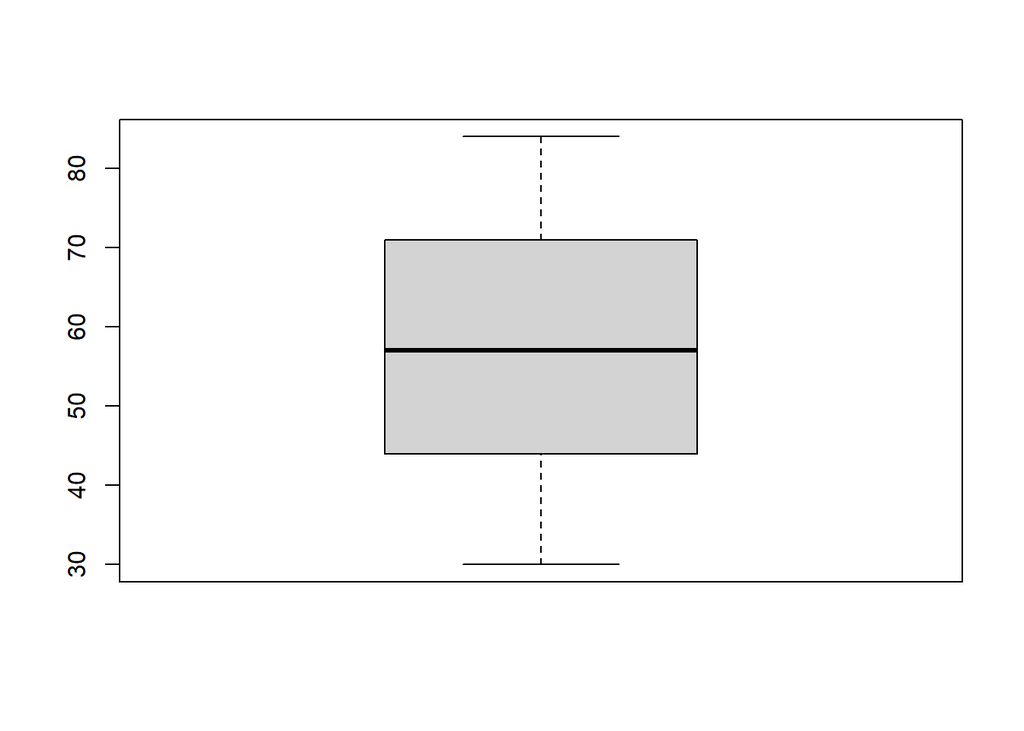

```r
drunk = sample$AGE[sample$ALCOHOL_CONSUMPTION=="YES"]
sober = sample$AGE[sample$ALCOHOL_CONSUMPTION=="NO"]
boxplot(sober)
```

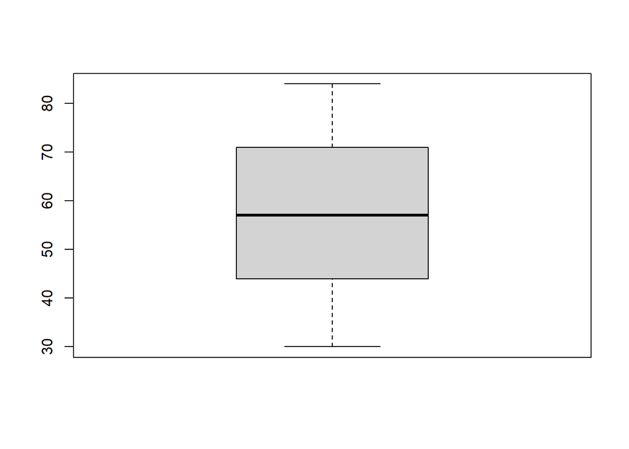

```r
boxplot(drunk)
```

From boxplots, we can see that there aren’t any outliers for both samples, so we don’t have to clean them from data set.

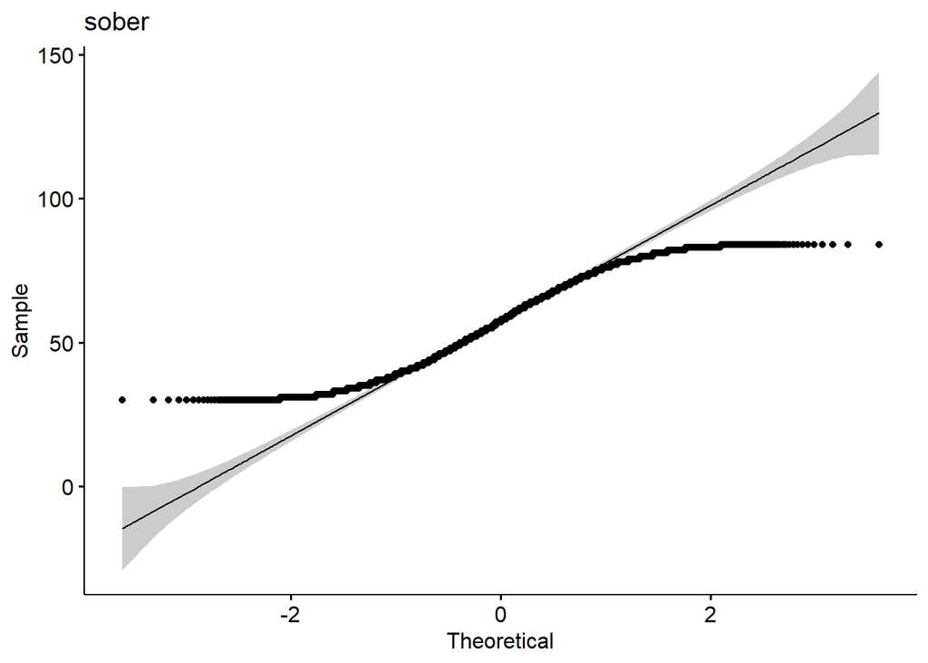

```r
ggqqplot(sober, conf.int = TRUE, conf.int.level = 0.95, title = "sober")
```

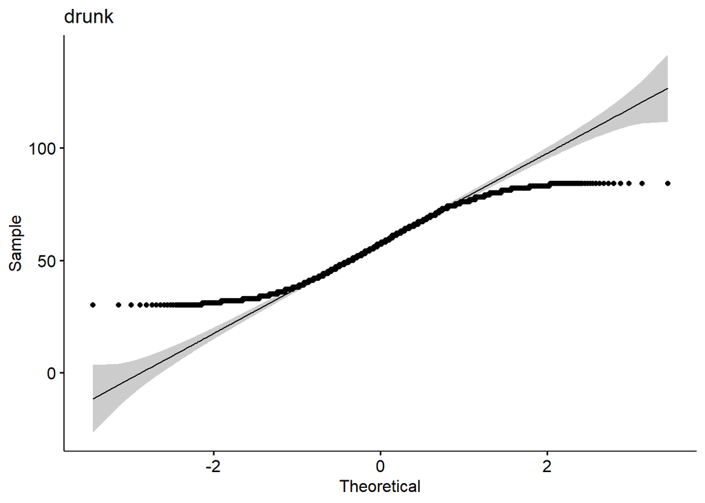

```r
ggqqplot(drunk, conf.int = TRUE, conf.int.level = 0.95, title = "drunk")
```

Ggplots show that distribution of our sample is most likely not normal. Now we want to find what is their PDF.

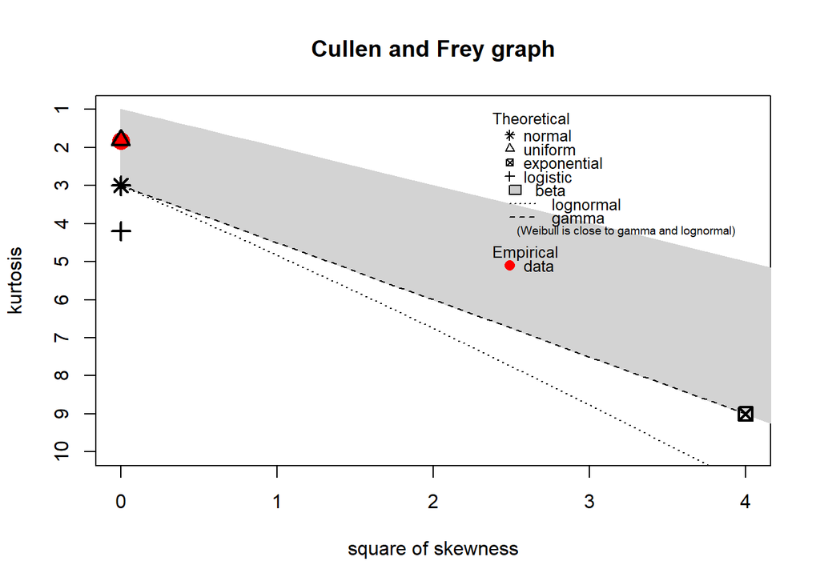

```
## summary statistics
## ------
## min:  30   max:  84
## median:  57
## mean:  57.24094
## estimated sd:  15.79467
## estimated skewness:  -0.0212469
## estimated kurtosis:  1.825445
```

```r
descdist(sober)
```

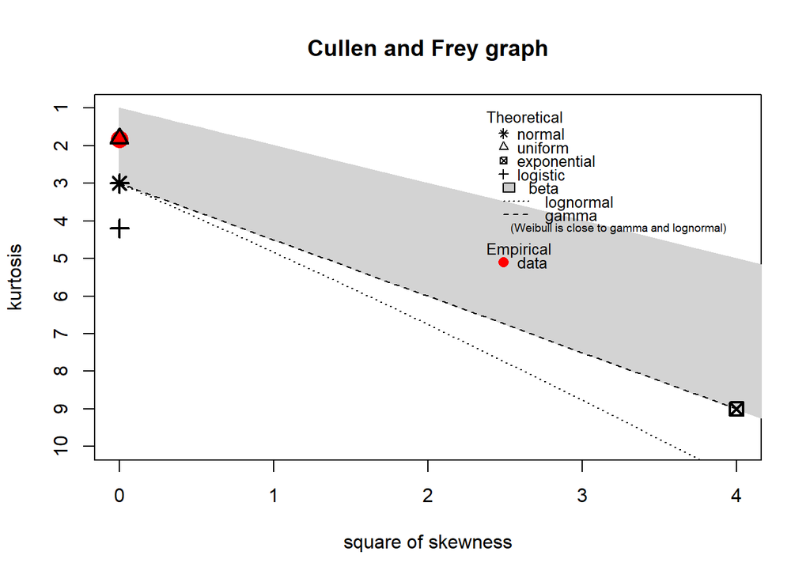

```
## summary statistics
## ------
## min:  30   max:  84
## median:  57
## mean:  57.18972
## estimated sd:  15.81193
## estimated skewness:  -0.01285026
## estimated kurtosis:  1.820157
```

```r
descdist(drunk)
```

From Cullen and Frey graph we clearly see that we deal with uniform distribution, but to be sure let’s check it with different plots, and Shapiro-Wilk test.

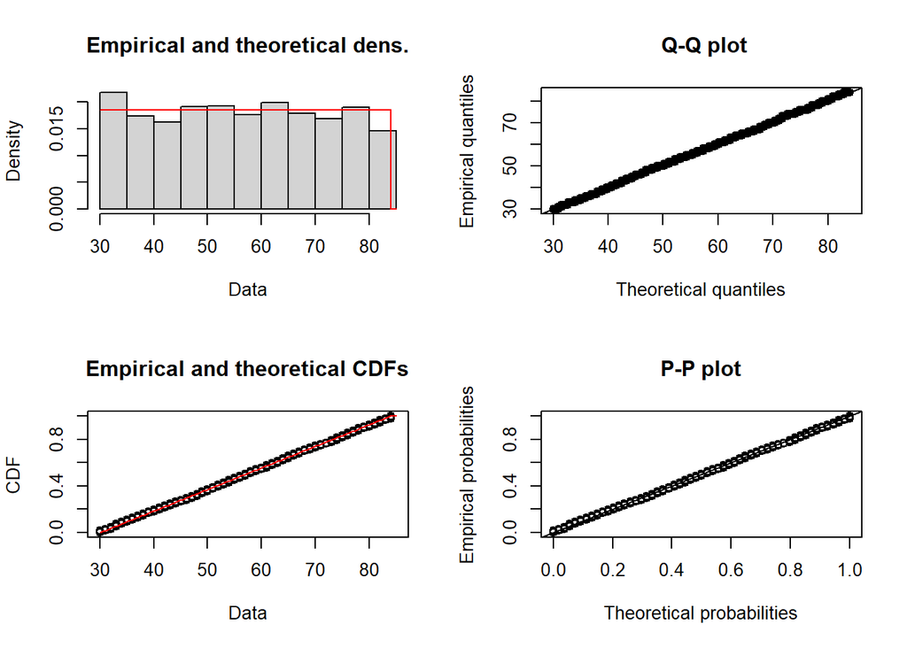

```r
fit_uni <-fitdist(drunk, "unif")
plot(fit_uni)
```

```r
shapiro.test(drunk)
```

```
##
##  Shapiro-Wilk normality test
##
## data:  drunk
## W = 0.95526, p-value < 2.2e-16
```

```r
shapiro.test(sober)
```

```
##
##  Shapiro-Wilk normality test
##
## data:  sober
## W = 0.95618, p-value < 2.2e-16
```

```r
mean(drunk)
```

```
## [1] 57.18972
```

```r
mean(sober)
```

```
## [1] 57.24094
```

```r
leveneTest(sample$AGE~sample$ALCOHOL_CONSUMPTION)
```

```
## Levene's Test for Homogeneity of Variance (center = median)
##         Df F value Pr(>F)
## group    1   2e-04 0.9885
##       4998
```

P-value of the test is equal to 0.9885, so we don’t reject Null Hypothesis about equality of variances. To finalize our task, we will use Wilcoxon test.

```r
wilcox.test(sober,drunk,paired = FALSE)
```

```
##
##  Wilcoxon rank sum test with continuity correction
##
## data:  sober and drunk
## W = 2864700, p-value = 0.9116
## alternative hypothesis: true location shift is not equal to 0
```

## TASK 2

Our task is to compare powers of t-test and Wilcoxon test under normality samples. Only assumption for samples is to be independent, that is why we chose to generate samples with rnorm function in R language.

```r
simulate_power = function(n, d, test_type = c("t", "wilcox"), conf = 0.1, iterations = 10000) {
  test_type = match.arg(test_type)
  rejections = 0
  for (i in 1:iterations) {
    x = rnorm(n, mean = 0, sd = 1)
    y = rnorm(n, mean = d, sd = 1)
    if (test_type == "t") {
      p_val = t.test(x, y, var.equal = TRUE)$p.value
    } else {
      p_val = wilcox.test(x, y)$p.value
    }
    if (p_val < conf) {
      rejections = rejections + 1
    }
  }
  return(rejections / iterations)
}


set.seed(2137)


sample_sizes = c(25, 50)
effect_sizes = c(1/8, 1/4, 1/2)
for (n in sample_sizes) {
  for (d in effect_sizes) {
    power_t = simulate_power(n, d, "t")
    power_w = simulate_power(n, d, "wilcox")
    cat(sprintf("n = %d, d = %.3f | t-test power = %.3f, Wilcoxon power = %.3f\n", n, d, power_t, power_w))
  }
}
```

```
## n = 25, d = 0.125 | t-test power = 0.130, Wilcoxon power = 0.133
## n = 25, d = 0.250 | t-test power = 0.221, Wilcoxon power = 0.214
## n = 25, d = 0.500 | t-test power = 0.536, Wilcoxon power = 0.513
## n = 50, d = 0.125 | t-test power = 0.169, Wilcoxon power = 0.164
## n = 50, d = 0.250 | t-test power = 0.350, Wilcoxon power = 0.339
## n = 50, d = 0.500 | t-test power = 0.801, Wilcoxon power = 0.779
```

Only thing that is left to complete, is to find number of samples, such that the estimation error is less than 0.005 with probability at least 99%.

```r
z = qnorm(0.995)
p = 0.1
m = 0.005
n_required = (z^2 * p * (1 - p)) / (m^2)
n_required
```

```
## [1] 23885.63
```

Calculations give us number “23885.63”. Sample size needs to be integer, so after rounding it we get 23886. That finalize our project.